# TP4-PCA

Mohamed-Aymane AKIL - Tariq Sereir - Mohamed Lemine Isselmou

2023-03-25

### *Data Preparation*

##### Question 1:

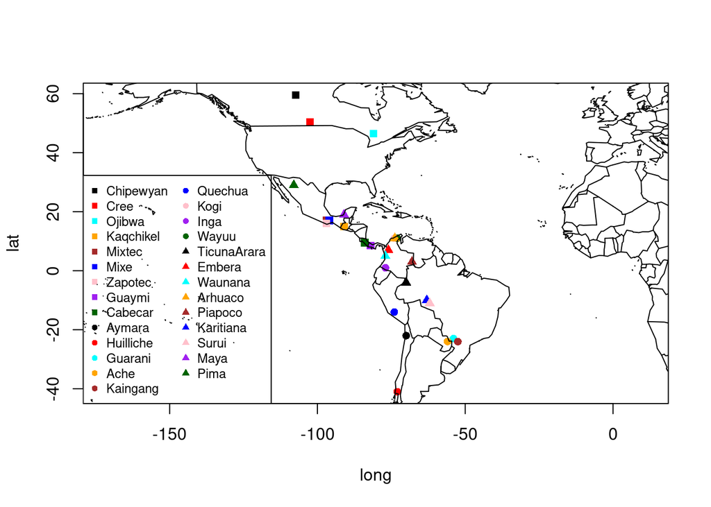

```r
# install.packages("fields")
NAm2 <- read.table("NAm2.txt", header=TRUE, stringsAsFactors = TRUE)
data.NAm2 <- as.data.frame(NAm2)
attach(data.NAm2)
coord <- unique(NAm2[, c("Pop","long","lat")])
mypop <- unique(NAm2$Pop)
npop <- length(mypop)
palcol <- c("black","red","cyan","orange","brown","blue","pink","purple","darkgreen")
mypch <- rep(15:17, each=length(mypop)/3)
mycol <- rep(palcol, length=length(mypop))
plot(coord[, c("long","lat")], pch=mypch, col=mycol, asp=1)
legend("bottomleft", legend=coord$Pop, col=mycol, pch=mypch,
       cex=.75, ncol=2)
library(maps)
library(fields)
map("world", add=TRUE)
```

Dans ce code ci-dessus, on effectue le traçage des différents tribus en Amérique(Chipewyan, Kogi,…). Le traçage continue les tribus avec leurs latitude et longitude correpondante dans la carte du monde.

##### Question 2:

Le modèle peut avoir un problème de surajustement (overfitting) car le nombre de variables explicatives est beaucoup plus grand que le nombre d’observations. Le rang de la matrice est inférieur a p (le nombre de prédicteurs). Rang(X) < p, ou X ∈ R^(N ×p) est la matrice de données.

```r
# fonction glance de la librairie broom qui est plus concice
library(broom)
NAaux <- NAm2[,-c(1:7)]
longModel <- lm(long~ ., data=NAaux)
# compte le nombre de coefficients dans le modèle qui ne sont pas manquants (i.e., qui ont une valeur)
print(sum(!is.na(coef(longModel))))
```

```
## [1] 494
```

```r
head(coef(longModel)[!is.na(coef(longModel))])
```

```
## (Intercept)      L1.125      L1.130      L1.135      L1.140      L1.142
##  1250.37453  -171.25567    44.75429   -54.57834  -264.33300  -792.47776
```

```r
# utilise le modèle de régression linéaire longModel pour prédire la longitude
longPredict <- predict(longModel, newdata = NAaux)
head(longPredict)
```

```
## Chipewyan29 Chipewyan31 Chipewyan33 Chipewyan35 Chipewyan37 Chipewyan39
##      -107.3      -107.3      -107.3      -107.3      -107.3      -107.3
```

```r
glance(longModel)
```

```
## # A tibble: 1 × 12
##   r.squared adj.r.squared sigma statistic p.value    df logLik   AIC   BIC
##       <dbl>         <dbl> <dbl>     <dbl>   <dbl> <dbl>  <dbl> <dbl> <dbl>
## 1         1           NaN   NaN       NaN     NaN   493    Inf  -Inf  -Inf
## # ℹ 3 more variables: deviance <dbl>, df.residual <int>, nobs <int>
```

### *Principal component analysis*

##### Question 3:

On utilise le scale.unit dans la fonction pca pour des variables d’unités différentes or dans notre cas, on a des marqueurs génétiques qui ne prennent que deux valeurs 0 ou 1, cependant, on peut comparer les graphes de pca obtenus le graphe de pca avec normalisation est plus lisible, les valeurs sont moins en “bloc”. De plus la variance expliquées par les 2 premières composantes sont supérieures avec sans normalisation.

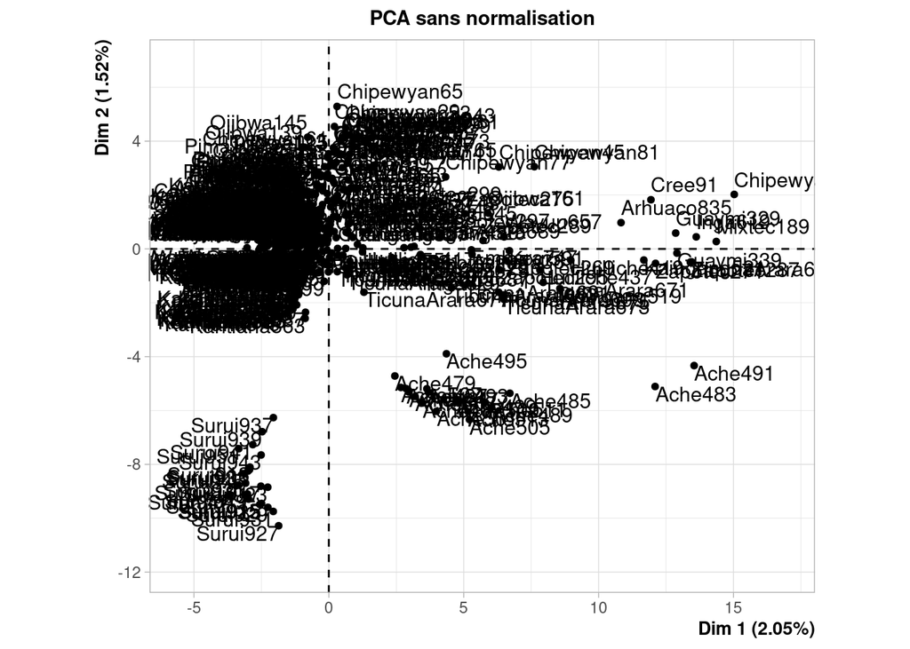

```r
NAm2GeneticData <- NAm2[, grep("L", colnames(NAm2), value=TRUE)]
library(FactoMineR)
pca.NAm2GeneticData <- PCA(NAm2GeneticData, scale.unit = FALSE, graph = FALSE)
plot.PCA(pca.NAm2GeneticData, title  = "PCA sans normalisation")
```

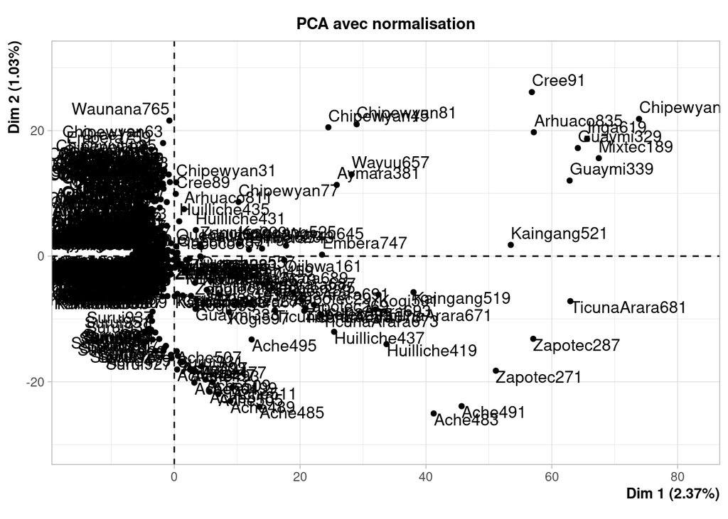

```r
pca.NAm2GeneticData.TRUE <- PCA(NAm2GeneticData, scale.unit = TRUE, graph = FALSE)
plot.PCA(pca.NAm2GeneticData.TRUE, title  = "PCA avec normalisation")
```

```r
#sum.pca <- summary(pca.NAm2GeneticData)
```

##### Question 4:

Pour les deux premières composantes on a le graphe suivant:

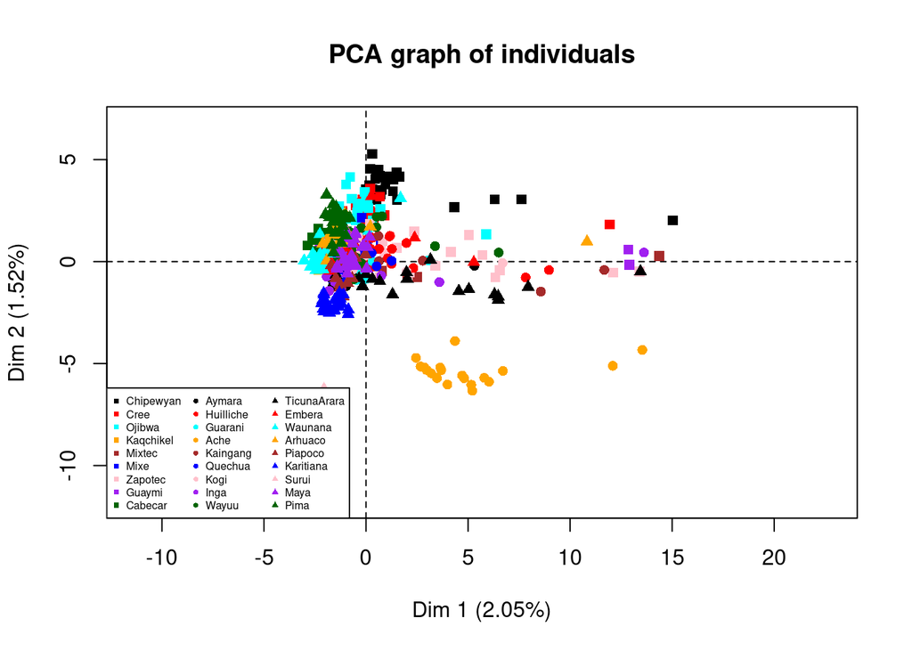

```r
mypop <- unique(NAm2$Pop)
npop <- length(mypop)
caxes = c(1,2)
plot(pca.NAm2GeneticData, axes= caxes, label="none", col.ind="white", graph.type="classic")
for (i in 1:npop)
{
    points(pca.NAm2GeneticData$ind$coord[which(NAm2$Pop == mypop[i]), caxes],
      col=mycol[i], pch=mypch[i])
}
legend("bottomleft", legend=mypop, col=mycol, pch=mypch, cex=.5, ncol=3)
```

Pour la troisième et quatrième composantes on a le graphe suivant:

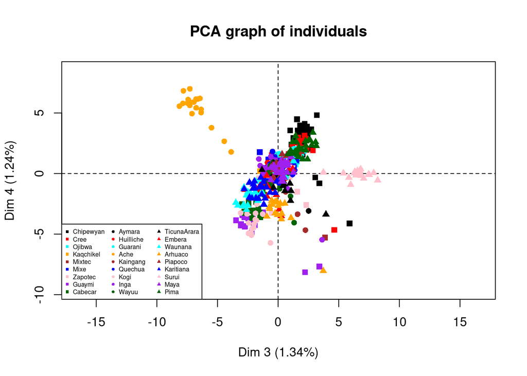

```r
mypop <- unique(NAm2$Pop)
npop <- length(mypop)
caxes = c(3,4)
plot(pca.NAm2GeneticData, axes= caxes, label="none", col.ind="white", graph.type="classic")
for (i in 1:npop)
{
    points(pca.NAm2GeneticData$ind$coord[which(NAm2$Pop == mypop[i]), caxes],
      col=mycol[i], pch=mypch[i])
}
legend("bottomleft", legend=mypop, col=mycol, pch=mypch, cex=.5, ncol=3)
```

##### Question 5:

D’après le graphe de la question 4, on a les variances capturées par les deux premières composantes sont respectivement: 2.05% et 1.52%. Et donc les deux composantes arrivent à captuer une variance de l’orde de 3.57% (assez faible). En effet, on remarque que les variances capturés par chaque composante sont assez faibles. Et donc on a besoin d’un nombre conséquent de composante si on veut représenter d’une bonne manière les marqueurs génétiques.

##### Question 6:

```r
matrice.pca <- as.matrix(pca.NAm2GeneticData$eig)
Nbr.estim <- estim_ncp(matrice.pca)
print(head(matrice.pca))
```

```
##        eigenvalue percentage of variance cumulative percentage of variance
## comp 1   8.847215              2.0500308                          2.050031
## comp 2   6.552942              1.5184137                          3.568445
## comp 3   5.763600              1.3355114                          4.903956
## comp 4   5.371611              1.2446819                          6.148638
## comp 5   4.896241              1.1345317                          7.283169
## comp 6   4.315458              0.9999556                          8.283125
```

```r
print(Nbr.estim)
```

```
## $ncp
## [1] 2
##
## $criterion
## [1] 1.000000e+00 1.770892e-01 3.180892e-30
```

En utilisant la fonction estim_ncp, on obtient une estimation d’un nombre optimal de composantes qui peuvent expliquer une part important de la variance. Or dans notre cas, on a un nombre de compsante égale à 2 avec une variance capturé de l’orde de 3.5%, ce qui insuffisant. Ainsi il faut trouvez une autre méthode pour estimer le nombre de composantes qui capture une partie importante de la variance.

### *Principal components regression (PCR)*

##### Question 7:

Cherchons d’abord les 100 premières composantes qui capturent le nombre le plus important de composante.

```r
pca.NAm2GeneticData <- prcomp(NAm2GeneticData)
pca.reg <- pca.NAm2GeneticData$x[,1:100]
```

Pour le modèle de la latitude:

```r
lm.NAm2.lat <- lm(lat ~ .,data = as.data.frame(pca.reg))
sum.lm.NAm2.lat <- summary(lm.NAm2.lat)
```

Pour le modèle de la longitude:

```r
lm.NAm2.long <- lm(long ~ .,data = as.data.frame(pca.reg))
sum.lm.NAm2.long <- summary(lm.NAm2.long)
```

##### Question 8:

On effectue le traçage des valeurs prédites de la longitude et la latitude après le fit de nos modèles.

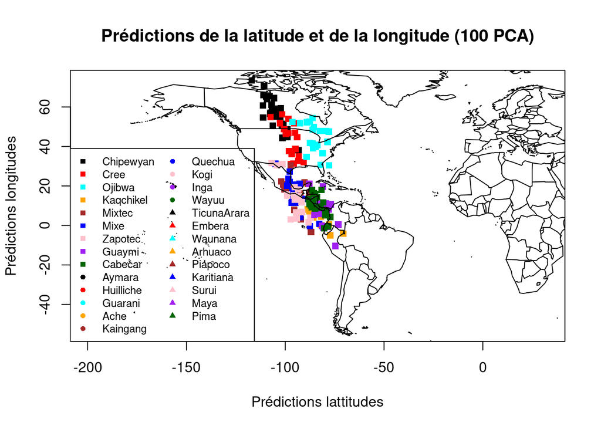

```r
library(maps)
plot(lm.NAm2.long$fitted.values, lm.NAm2.lat$fitted.values, xlab = "Prédictions lattitudes", asp = 1, ylab = "Prédictions longitudes", col = "white", main = "Prédictions de la latitude et de la longitude (100 PCA)")
for (i in 1:npop) {
  lines(lm.NAm2.long$fitted.values[which(NAm2[,3] == mypop[i])], lm.NAm2.lat$fitted.values[which(NAm2[,3] == mypop[i])], type = "p", col = palcol[i], pch = mypch[i])
}
legend("bottomleft", legend = mypop, col = palcol, lty = -1, pch = mypch, cex = 0.75, ncol = 2, lwd = 2)
map("world", add = TRUE)
```

Le premier graphique montre que les individus d’une même tribu se superposent car ils ont la même latitude et longitude. Dans le deuxième graphique, nous avons utilisé un modèle de régression basé sur les 100 premières composantes principales pour prédire la latitude et la longitude de chaque individu. Bien que ce modèle ait une bonne précision pour prédire la localisation de populations éloignées, il n’est pas suffisamment précis pour distinguer les individus de tribus proches. En conclusion, trouver la localisation géographique d’individus en dehors de la base de données à partir de leurs marqueurs génétiques ne sera pas toujours exact, et ce modèle peut prédire de manière erronée leur localisation. Il pourrait être utile de combiner ces méthodes avec une classification utilisant l’algorithme de k-means autour de la localisation exacte de chaque tribu.

### *PCR And Cross-validation*

##### Question 9:

```r
idx <- sample(10,size=nrow(NAm2),replace=TRUE)
```

##### Question 10:

Effectuons la prédiction sur la validation set

```r
donnees <- data.NAm2[,-c(1:8)]
Y <- data.NAm2[c(7,8)]
cross.validation <- function(naxes){
  # une dataframe vide
  pred.coord.cf <- data.frame(matrix(ncol=2,nrow=494))
  colnames(pred.coord.cf) <- c("lat","long")
  # une variable qui calcule l'erreur
  erreur.entrainement = 0

  for (i in 1:10){

    # séparation en 2 parties: entrainement et validation
    data.train <- donnees[idx != i,]
    data.test <- donnees[idx == i,]

    # recentrage des points de données en utilisant l'ensemble d'entrainement
    data.train <- data.train - colMeans(data.train)
    data.test <- data.test - colMeans(data.test)
    # On effectue une PCA sur notre data d'entrainement

    pca.data.train <- prcomp(data.train)
    A.data.train <- pca.data.train$x[,1:naxes]
    # On construit nos modèles pour la régression
    lm.NAm2.lat.1 <- lm(lat[idx != i] ~.,data = as.data.frame(A.data.train))
    lm.NAm2.long.1 <- lm(long[idx != i]  ~.,data = as.data.frame(A.data.train))
    # On obtient la matrice de projection en se limitant au naxes vecteurs propres premiers
    projection.matrix = pca.data.train$rotation[,1:naxes]
    # On projete notre data sur la matrice de projection
    A.data.test <- as.matrix(data.test)%*% as.matrix(projection.matrix)
    # On calcule les valeurs prédites
    pred.lat <- predict(lm.NAm2.lat.1, newdata = data.frame(A.data.test))
    pred.long <- predict(lm.NAm2.long.1, newdata = data.frame(A.data.test))
    # On conserve ses valeurs dans pred.coord.cf
    pred.coord.cf[idx == i, "lat"] = pred.lat
    pred.coord.cf[idx == i, "long"] = pred.long
    # On calcule l'erreur d'entrainement
    erreur.entrainement = erreur.entrainement + mean(rdist.earth.vec(Y[idx!= i, ],cbind(lm.NAm2.lat.1$fitted.values,lm.NAm2.long.1$fitted.values),miles = F))
  }
  erreur.entrainement = erreur.entrainement/10
  erreur.test = mean(rdist.earth.vec(pred.coord.cf,Y,miles = F))
  return (list(erreur.entrainement,erreur.test))
}
```

```r
erreur = cross.validation(4)
cat("L'erreur d'entrainement de notre modèle est: ",erreur[[1]],"\n")
```

```
## L'erreur d'entrainement de notre modèle est:  1081.162
```

```r
cat("L'erreur de prédiction de notre modèle est: ",erreur[[2]])
```

```
## L'erreur de prédiction de notre modèle est:  1396.018
```

##### Question 11:

```r
naxes <- seq(from = 2, to = 440, by = 10)
erreur.entrainement.list <- c()
erreur.test.list <- c()
for(j in naxes){
  erreur = cross.validation(j)
  erreur.entrainement.list <- c(erreur.entrainement.list,erreur[[1]])
  erreur.test.list <- c(erreur.test.list,erreur[[2]])
}
```